# Imputation of Longitudinal or Multi-level Data

## Preface

### R packages

In this practical, a number of R packages are used. If any of them are not installed you may be able to follow the practical but will not be able to run all of the code. The packages used (with versions that were used to generate the solutions) are:

- R version 3.6.0 (2019-04-26)
- `mice` (version: 3.4.0)
- `nlme` (version: 3.1.139)
- `JointAI` (version: 0.5.1)
- `ggplot2` (version: 3.1.1)
- `reshape2` (version: 1.4.3)

### Help files

You can find help files for any function by adding a `?` before the name of the function.

Alternatively, you can look up the help pages online at https://www.rdocumentation.org/ or find the whole manual for a package at https://cran.r-project.org/web/packages/available_packages_by_name.html

### Dataset

In this practical we will work with data on from a trial on primary biliary cirrhosis (PBC) of the liver.

To get the **pbclong** data, load the file `pbclong.RData`. You can download it [here](https://nerler.github.io/EP16_Multiple_Imputation/practical/data/index.html). To load this dataset, you can use the command `file.choose()` which opens the explorer and allows you to navigate to the location of the downloaded file on your computer. If you know the path to the file, you can also use `load("<path>/<pbclong.RData")`.

The variables contained in the dataset `pbclong` are:

| `id` | patient identifier |
| --- | --- |
| `protime` | blood clotting time (the longitudinal outcome) |
| `year` | continuously measured year of follow-up time (the time variable) |
| `sex` | patients’ sex (f: female, m: male) |
| `trt` | treatment group (0: D-penicillmain, 1: placebo) |
| `age` | patients’ age at intake |
| `ascites` | presence of ascites at baseline (0:no, 1:yes) |
| `bili` | serum bilirubin level at baseline |
| `chol` | serum cholesterol level at baseline |
| `albumin` | serum albumin level at follow-up (time-varying) |

The variables have the following distributions and proportions of missing values:

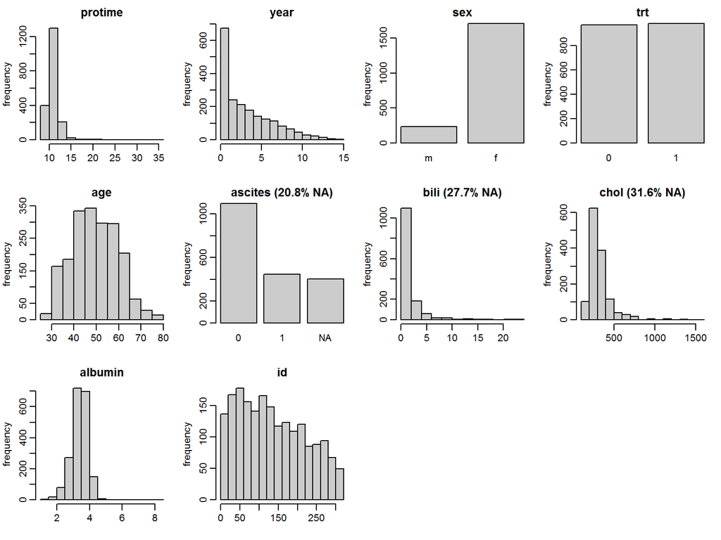

The missing data pattern is:

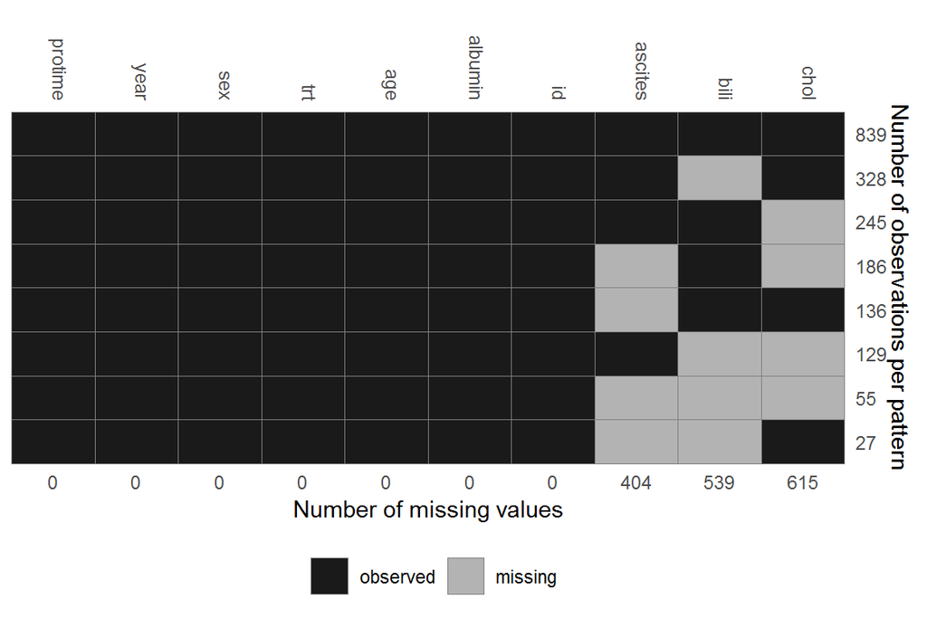

The longitudinal outcome `protime` shows relatively linear trajectories over time:

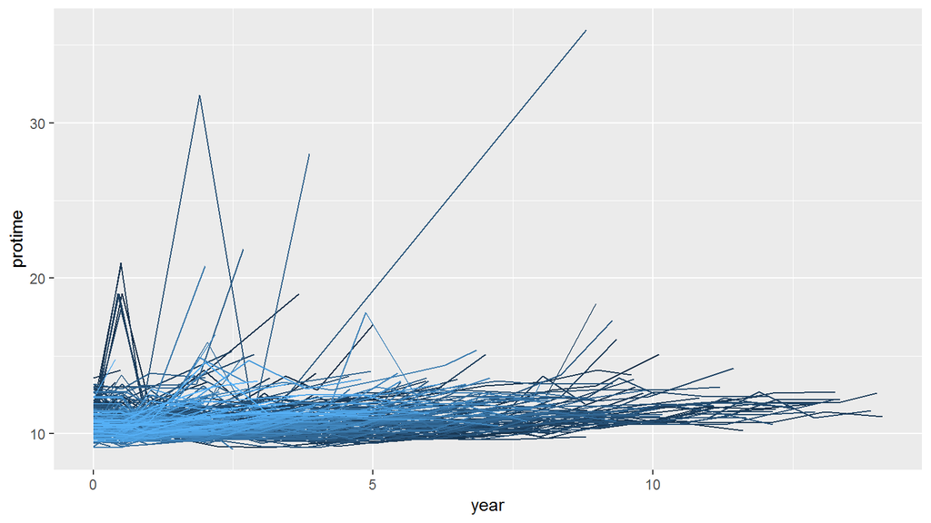

To analyse the trajectories of `protime` we want to use the following linear mixed effects model with random intercept and slope (either using `lme` from the package **nlme** or using `lmer` from the package **lme4**):

```r
# using package nlme
lme(protime ~ year + sex + trt + age + ascites + bili + chol + albumin, random = ~year|id)


# using package lme4
lmer(protime ~ year + sex + trt + age + ascites + bili + chol + albumin + (year|id))
```

### Imputation using **mice**

For imputation of longitudinal data, the **mice** package provides special imputation methods that take into account the two-level structure of the data.

In the `pbclong` data, missing values occur in baseline covariates only. For such variables, the imputation methods

- `2lonly.pmm` and
- `2lonly.norm`

are available.

The `predictorMatrix` requires some extra specification to identify the “id” variable (set to -2) and the random effects structure (set to 2).

#### Task 1

Run the setup imputation and perform the necessary changes in the imputation method and predictor matrix.

**mice** does not recognize automatically that the data are multil-level, hence the settings chosen by default are not correct. You need to specify imputation methods for all incomplete variables.

#### Solution 1

```r
micelong0 <- mice(pbclong, maxit = 0)
meth_micelong <- micelong0$method
pred_micelong <- micelong0$predictorMatrix

meth_micelong[c("ascites", "bili", "chol")] <- "2lonly.pmm"

pred_micelong[, "id"] <- -2
pred_micelong[, "year"] <- 2

# check the predictor matrix
pred_micelong
```

```
##         protime year sex trt age ascites bili chol albumin id
## protime       0    2   1   1   1       1    1    1       1 -2
## year          1    2   1   1   1       1    1    1       1 -2
## sex           1    2   0   1   1       1    1    1       1 -2
## trt           1    2   1   0   1       1    1    1       1 -2
## age           1    2   1   1   0       1    1    1       1 -2
## ascites       1    2   1   1   1       0    1    1       1 -2
## bili          1    2   1   1   1       1    0    1       1 -2
## chol          1    2   1   1   1       1    1    0       1 -2
## albumin       1    2   1   1   1       1    1    1       0 -2
## id            1    2   1   1   1       1    1    1       1 -2
```

#### Task 2

- run the imputation with the adapted imputation method `meth_micelong` and predictor matrix `pred_micelong`
- analyse the imputed data
- pool the results

#### Solution 2

```r
micelong <- mice(pbclong, meth = meth_micelong, pred = pred_micelong,
                 maxit = 20, printFlag = FALSE)

micelong_mira <- with(micelong, lme(protime ~ year + sex + trt + age +
                                      ascites + bili + chol + albumin,
                                    random = ~year|id)
)

# alternative:
micelong_mira <- with(micelong, lmer(protime ~ year + sex + trt + age +
                                      ascites + bili + chol + albumin +
                                    (year|id))
)

summary(pool(micelong_mira), conf.int = TRUE)
```

|  | estimate | std.error | statistic | df | p.value | 2.5 % | 97.5 % |
| --- | --- | --- | --- | --- | --- | --- | --- |
| (Intercept) | 12.1811568181 | 0.5039317832 | 24.1722337 | 34.892851 | 0.000000e+00 | 11.158008597 | 13.204305040 |
| year | 0.1781994229 | 0.0257260984 | 6.9267955 | 1151.985904 | 7.142731e-12 | 0.127724164 | 0.228674681 |
| sexf | -0.3375076314 | 0.1485490858 | -2.2720277 | 161.637047 | 2.326855e-02 | -0.630854813 | -0.044160450 |
| trt1 | -0.0500854898 | 0.0969272971 | -0.5167326 | 114.768817 | 6.054421e-01 | -0.242083923 | 0.141912943 |
| age | 0.0008351788 | 0.0053196720 | 0.1569982 | 37.941944 | 8.752738e-01 | -0.009934475 | 0.011604833 |
| ascites1 | 0.6049913346 | 0.1114172260 | 5.4299623 | 52.522521 | 6.870576e-08 | 0.381469245 | 0.828513424 |
| bili | 0.1003436279 | 0.0340560177 | 2.9464287 | 5.695063 | 3.279344e-03 | 0.015917922 | 0.184769333 |
| chol | -0.0002069802 | 0.0006179754 | -0.3349328 | 6.524071 | 7.377367e-01 | -0.001690150 | 0.001276189 |
| albumin | -0.4754531142 | 0.0715464986 | -6.6453722 | 749.585561 | 4.655676e-11 | -0.615908463 | -0.334997765 |

### Imputation using **JointAI**

To analyse incomplete longitudinal data a linear mixed model the R package **JointAI** provides the function `lme_imp()`.

The specification of the main model components is analogous to the function `lme()` from the **nlme** package.

For the specification of the other arguments of `lme_imp()`, refer to the [help page](https://nerler.github.io/JointAI/reference/model_imp.html), to the vignette on [Model Specification](https://nerler.github.io/JointAI/articles/ModelSpecification.html#MultiLevelStructure) or to the details given in the practical on [Imputation with Non-linear Associations](https://nerler.github.io/EP16_Multiple_Imputation/practical/minonlin/MInonlin.html).

#### Task

Run the imputation (start with `n.iter = 500`; this will take a few seconds) and check the `traceplot()`. If you are satisfied by convergence and mixing of the chains, get the model `summary()`.

#### Solution

```r
library(JointAI)
JointAIlong <- lme_imp(protime ~ year + sex + trt + age + ascites + bili + chol + albumin,
    random = ~year|id, data = pbclong, n.iter = 1000)
```

```
## This is new software. Please report any bugs to the package maintainer.
```

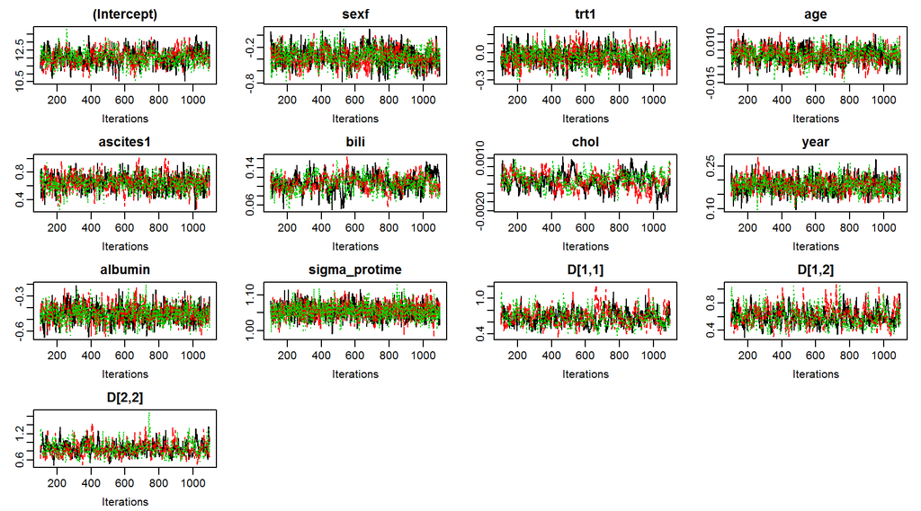

```r
traceplot(JointAIlong)
```

```r
summary(JointAIlong)
```

```
##
##  Linear mixed model fitted with JointAI
##
## Call:
## lme_imp(fixed = protime ~ year + sex + trt + age + ascites +
##     bili + chol + albumin, data = pbclong, random = ~year | id,
##     n.iter = 1000)
##
## Posterior summary:
##                  Mean       SD     2.5%     97.5% tail-prob. GR-crit
## (Intercept) 12.047542 0.466256 11.17893 13.015706     0.0000    1.00
## sexf        -0.358370 0.147639 -0.64850 -0.064554     0.0153    1.01
## trt1        -0.038474 0.091112 -0.21667  0.139299     0.6860    1.00
## age          0.002088 0.004831 -0.00750  0.011444     0.6613    1.01
## ascites1     0.651306 0.110761  0.43089  0.866094     0.0000    1.01
## bili         0.107509 0.017151  0.07433  0.140827     0.0000    1.01
## chol        -0.000279 0.000453 -0.00118  0.000628     0.5293    1.05
## year         0.182740 0.026122  0.13415  0.234779     0.0000    1.02
## albumin     -0.451883 0.071856 -0.59413 -0.307351     0.0000    1.01
##
## Posterior summary of random effects covariance matrix:
##         Mean    SD  2.5% 97.5% tail-prob. GR-crit
## D[1,1] 0.674 0.129 0.458 0.948               1.01
## D[1,2] 0.597 0.126 0.390 0.869          0    1.02
## D[2,2] 0.858 0.151 0.612 1.195               1.01
##
## Posterior summary of residual std. deviation:
##               Mean   SD 2.5% 97.5% GR-crit
## sigma_protime 1.06 0.02 1.02  1.09       1
##
##
## MCMC settings:
## Iterations = 101:1100
## Sample size per chain = 1000
## Thinning interval = 1
## Number of chains = 3
##
## Number of observations: 1945
## Number of groups: 312
```

### Comparison of the results for the longitudinal pbc data

Here is how the pooled results from these imputations compare:

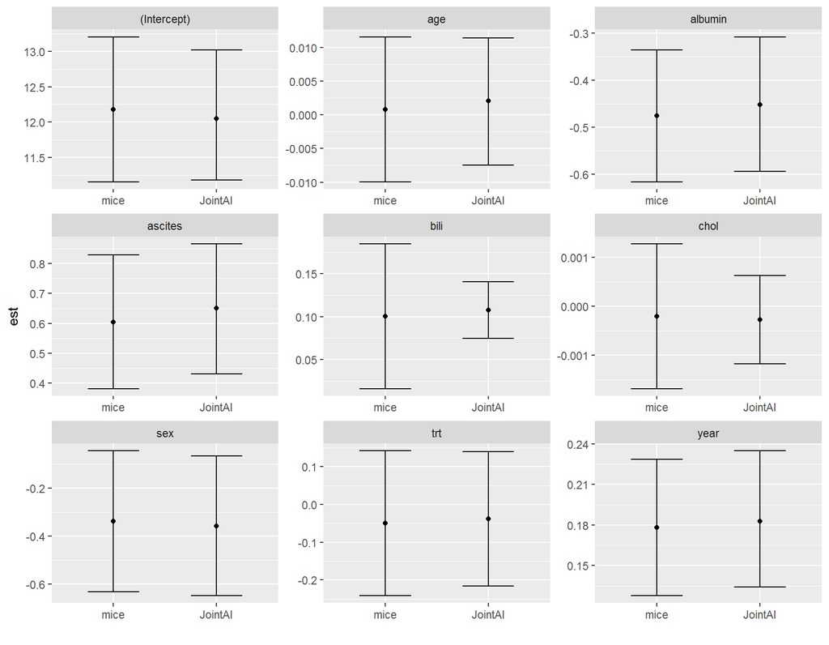

© Nicole Erler